# Clustering

Clustering Matheus Leal 20 de outubro de 2019

## Agrupamento

### Between/totss

Outra medida comumente usada no kmeans é *comparar a distância (quadrática) entre o centro dos clusters e o centro dos dados com a distância (quadrática) entre os pontos todos nos dados e o centro dos dados*.

Quebrando essa ideia para ficar mais fácil de entender:

Primeiro, o *centro dos dados* é um ponto imaginário na média de todas as variáveis. É um ponto que está no meio dos dados. Em uma situação onde cada ponto é um grupo (e os grupos são os mais coesos possíveis), a soma das distâncias dos grupos para o centro dos dados é igual à soma da distância dos pontos para o centro dos dados. Generalizando: se houver estrutura de grupos e ela estiver capturada pelo agrupamento, o somatório da distância do centro de cada grupo para o centro geral dos dados será um valor alto.

Para medir para quais valores de `k` isso acontece, calculamos a *distância do centro de cada cluster para o centro dos dados* e multiplicamos pelo número de pontos nesse cluster. Somando esse valor para todos os clusters, temos `betweenss` abaixo.

Se esse valor for próximo do somatório total das distâncias dos pontos para o centro dos dados (`totss`), os pontos estão próximos do centro de seu cluster. Essa proporção pode ser usada para definir um bom valor de `k`. Quando ela para de crescer, para de valer à pena aumentar `k`.

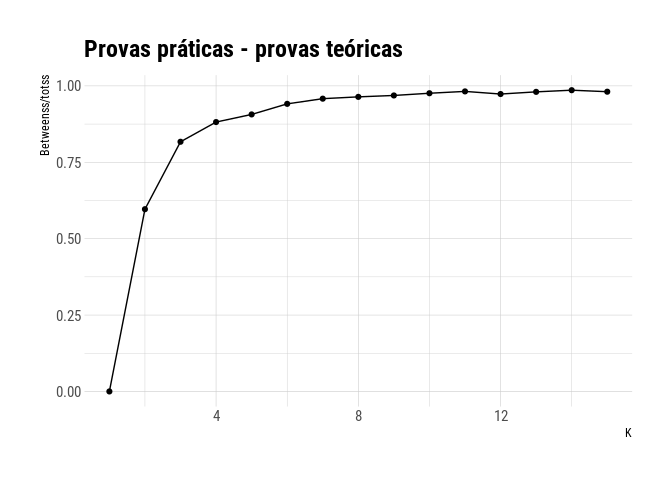

O bom valor de k parece ser 3, que vai ser o número de clusters para o nosso algoritmo de agrupamento.

### K-means

O algoritmo nos da a seguinte distribuição para os grupos:

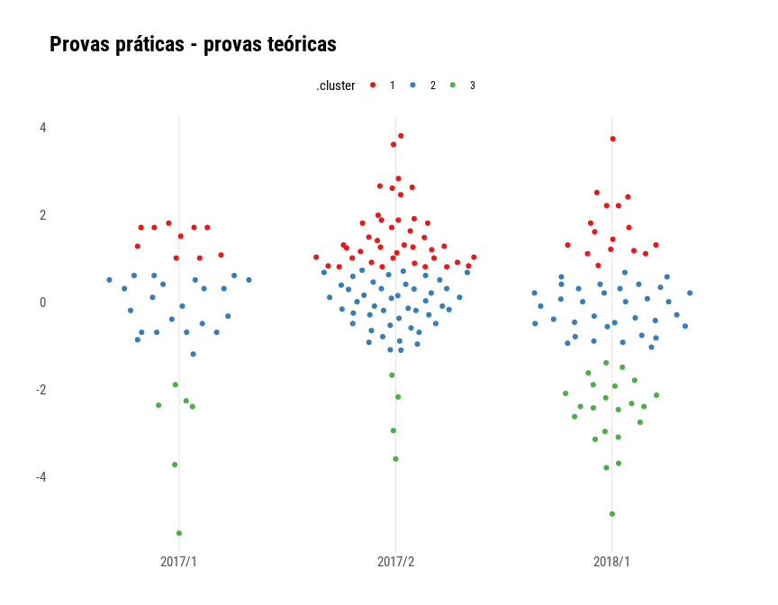

Algumas medidas para os grupos:

```
# A tibble: 3 x 4
  .cluster desvio_padrao mediana variancia
  <fct>            <dbl>   <dbl>     <dbl>
1 1                0.702  1.30       0.493
2 2                0.523 -0.1000     0.274
3 3                0.913 -2.4        0.834
```

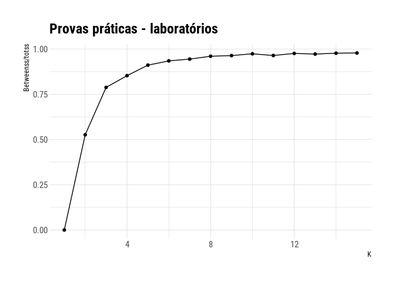

O bom valor de k parece ser 4, que vai ser o número de clusters para o nosso algoritmo de agrupamento.

O algoritmo nos da a seguinte distribuição para os grupos:

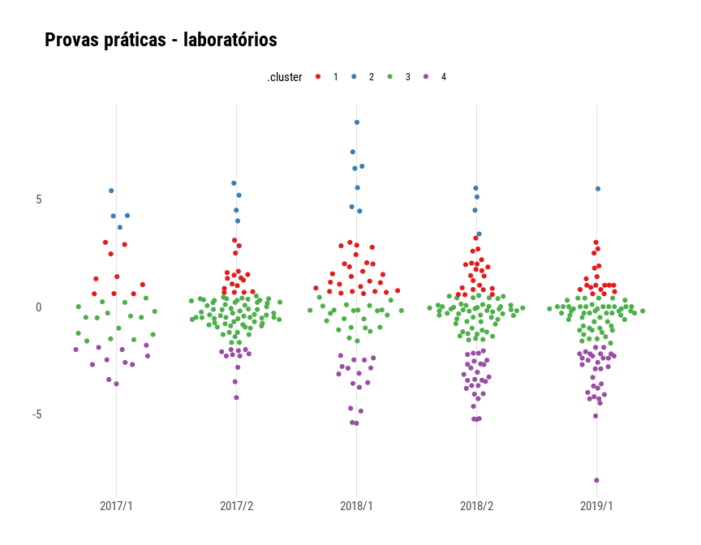

Algumas medidas para os grupos:

```
# A tibble: 4 x 4
  .cluster desvio_padrao mediana variancia
  <fct>            <dbl>   <dbl>     <dbl>
1 1                0.772    1.30     0.596
2 2                1.26     5.16     1.60
3 3                0.570   -0.3      0.325
4 4                1.08    -2.83     1.18
```

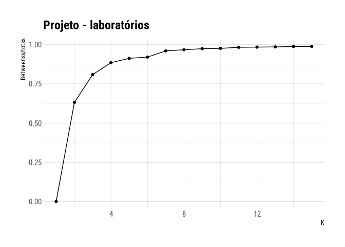

O bom valor de k parece ser 4, que vai ser o número de clusters para o nosso algoritmo de agrupamento.

O algoritmo nos da a seguinte distribuição para os grupos:

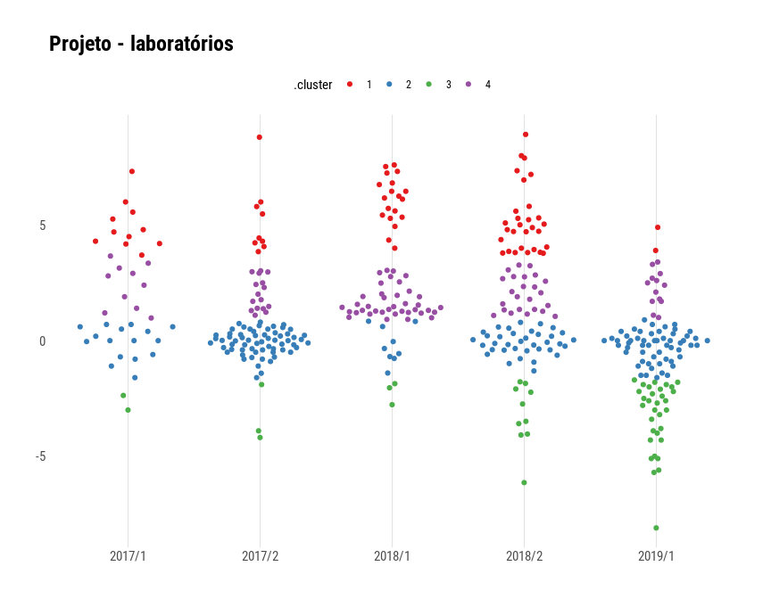

Algumas medidas para os grupos:

```
# A tibble: 4 x 4
  .cluster desvio_padrao mediana variancia
  <fct>            <dbl>   <dbl>     <dbl>
1 1                1.33   5.16       1.77
2 2                0.581 -0.0400     0.337
3 3                1.38  -2.76       1.90
4 4                0.747  1.79       0.559
```

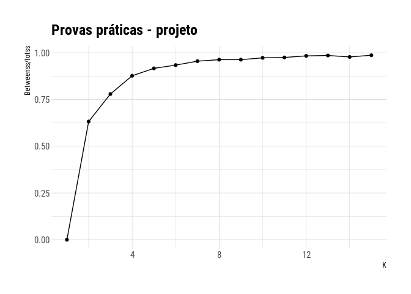

O bom valor de k parece ser 4, que vai ser o número de clusters para o nosso algoritmo de agrupamento.

O algoritmo nos da a seguinte distribuição para os grupos:

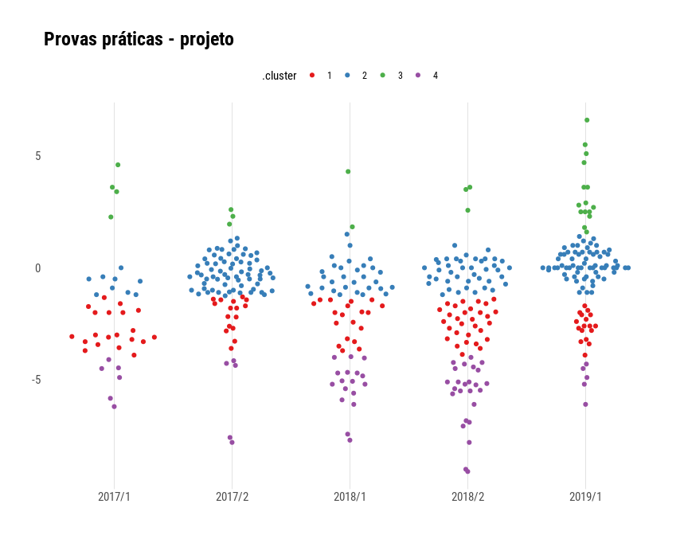

Algumas medidas para os grupos:

```
# A tibble: 4 x 4
  .cluster desvio_padrao mediana variancia
  <fct>            <dbl>   <dbl>     <dbl>
1 1                0.742 -2.4        0.550
2 2                0.659 -0.0900     0.434
3 3                1.24   2.8        1.53
4 4                1.25  -5.14       1.56
```

## Clusterizando com avaliações individuais

### K-means

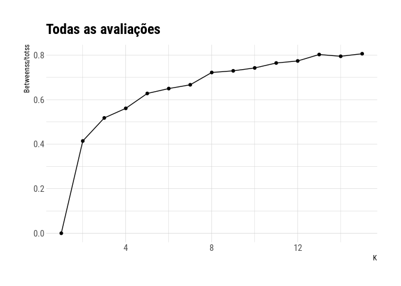

[figure not shown]

### PCA

|  | PC1 | PC2 | PC3 | PC4 | PC5 | PC6 | PC7 | PC8 |
| --- | --- | --- | --- | --- | --- | --- | --- | --- |
| lab_2 | 0.1715150 | -0.3914212 | 0.1814781 | -0.6759858 | 0.1307504 | -0.0937890 | 0.5490461 | 0.0117167 |
| lab_3 | 0.2146110 | -0.3688575 | 0.2181086 | -0.3021940 | -0.0868367 | 0.4661798 | -0.6738883 | 0.0020317 |
| lab_4 | 0.3646880 | -0.6686849 | -0.4451908 | 0.4475538 | 0.0721096 | -0.0755674 | 0.0760017 | 0.0683925 |
| lab_5 | 0.4814726 | 0.4333377 | -0.6234925 | -0.3757487 | 0.1702734 | -0.0010416 | -0.1396849 | 0.0443467 |
| primeira_prova | 0.3713364 | 0.0886078 | 0.4741091 | 0.1505626 | 0.5541578 | -0.4685599 | -0.2394015 | 0.1511857 |
| ultima_prova | 0.4379318 | 0.2464918 | 0.2665372 | 0.2826138 | 0.0132735 | 0.6303586 | 0.3990387 | 0.1994614 |
| projeto | 0.3296127 | 0.0609795 | 0.1377402 | -0.0300152 | -0.7706895 | -0.3766228 | -0.0305034 | 0.3619755 |
| media_parcial | 0.3484136 | 0.0590304 | 0.1332772 | 0.0824007 | -0.1998539 | -0.0970748 | 0.0407354 | -0.8941735 |

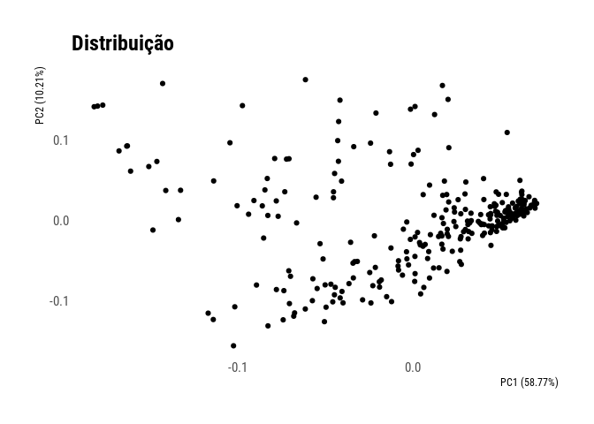

### PCA + K-means

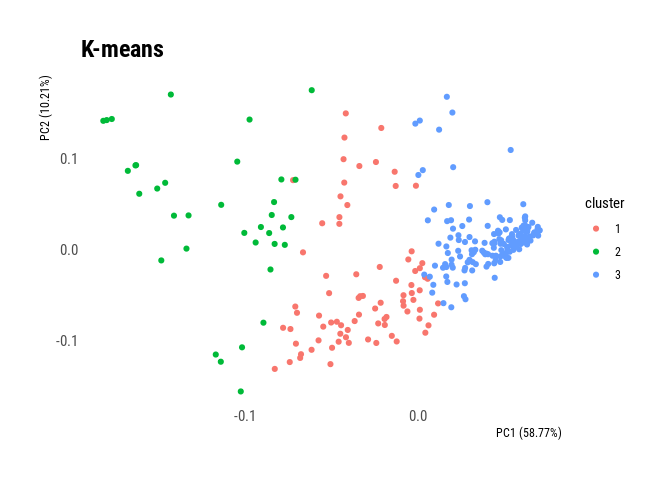

### PCA + Clara

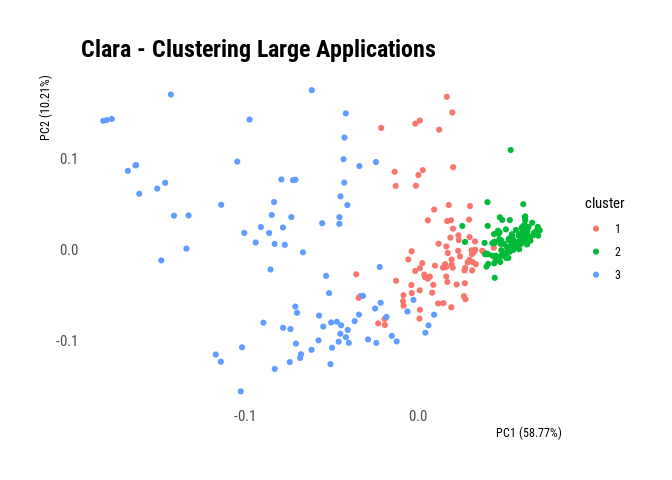

Clara: https://www.datanovia.com/en/lessons/clara-in-r-clustering-large-applications/

### PCA + Fanny

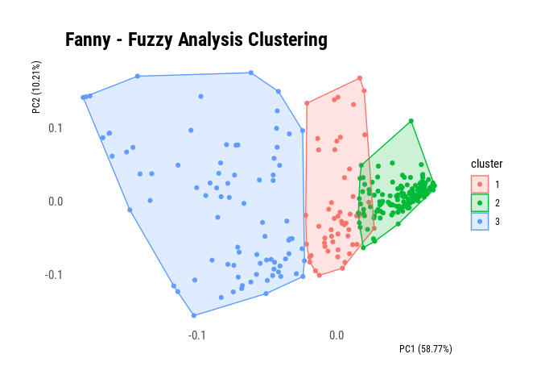

Fanny: https://www.datanovia.com/en/lessons/fuzzy-clustering-essentials/

### Clusterizando com médias

### K-means

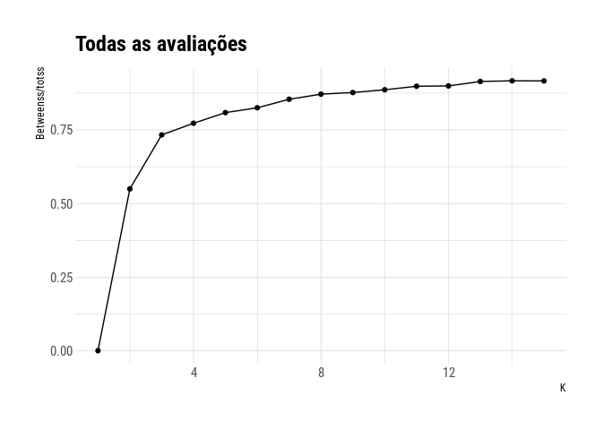

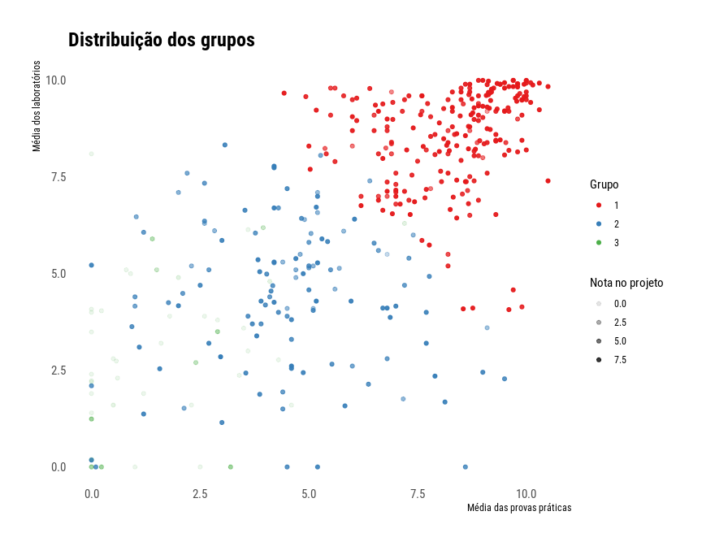

### PCA

|  | PC1 | PC2 | PC3 |
| --- | --- | --- | --- |
| media_labs | -0.5494064 | 0.6120139 | -0.5688511 |
| media_provas | -0.6108884 | 0.1702655 | 0.7731915 |
| projeto | -0.5700596 | -0.7723009 | -0.2803273 |

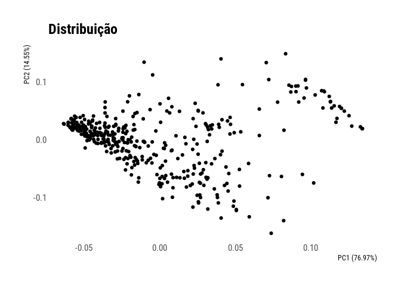

### PCA + K-means

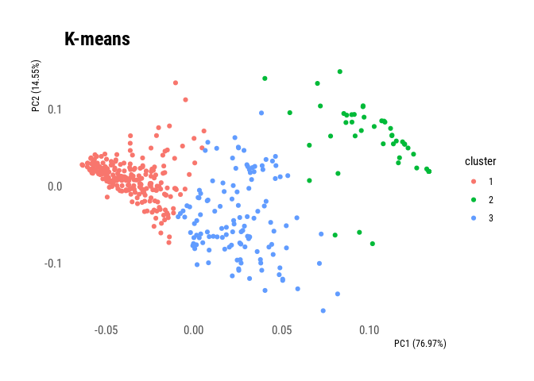

### PCA + Clara

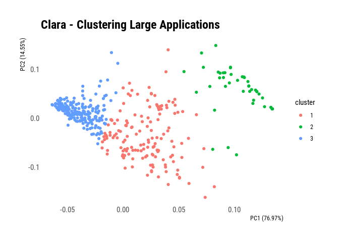

Clara: https://www.datanovia.com/en/lessons/clara-in-r-clustering-large-applications/

### PCA + Fanny

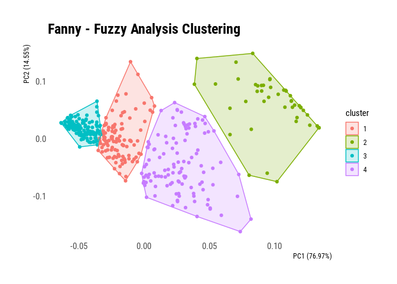

Fanny: https://www.datanovia.com/en/lessons/fuzzy-clustering-essentials/